# Part II - (PISA 2012 Dataset Analysis)

## by (Saeed Ashri)

## Investigation Overview

In this prject, Analysis of datase of pisa 2012 has Three key findings:

- Showing the distribution of scores in Math, Reading, and Science.
- Displaying the relationship between the scores in Math, Reading, and Science with genders.
- Illstrating the correlation between subjects' scores, genders, and parents' education levels.

## (Distribution of Scores)

The three histograms show the normal distribution of scores in Math, Reading, and Science. It can be seen, the red line shows the median of scores which is less than 500 points.

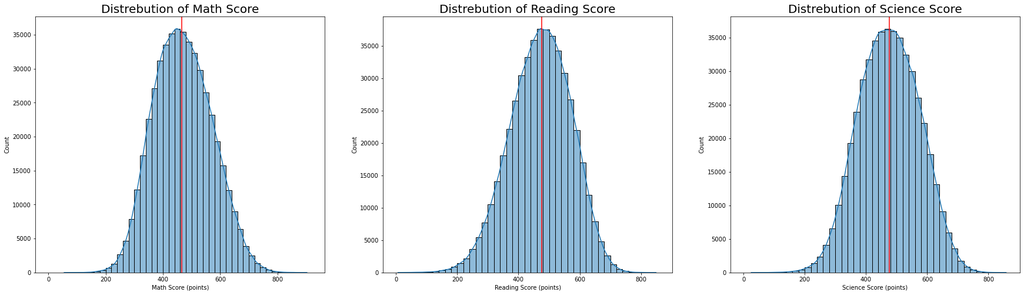

## (Relationship between Scores and Gender)

In this part, the box plots show the relationship between scores in Math, Reading, and Science with genders. All scores are nearly the same except the reading score is highest for females.

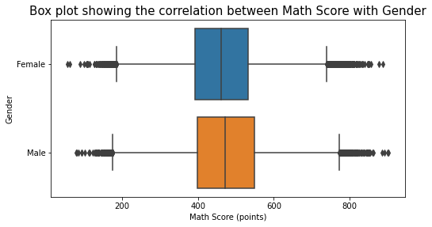

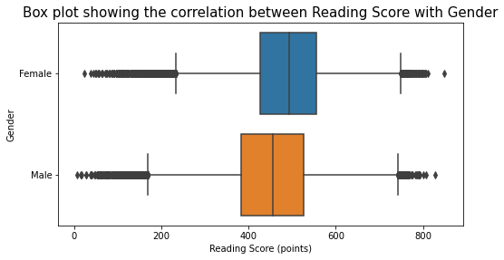

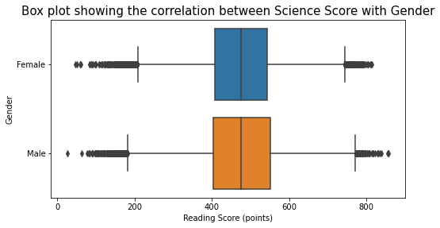

## (Correlation between scores, genders, and parents' education levels)

The three box plots illustrate the correlation between subjects' scores, genders, and parents' education levels. It can be seen, the scores of all genders are nearly the same but students who are parents have master's or doctoral certificates have high scores.

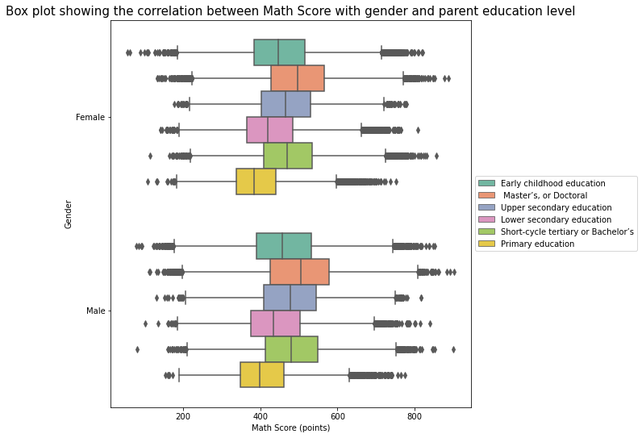

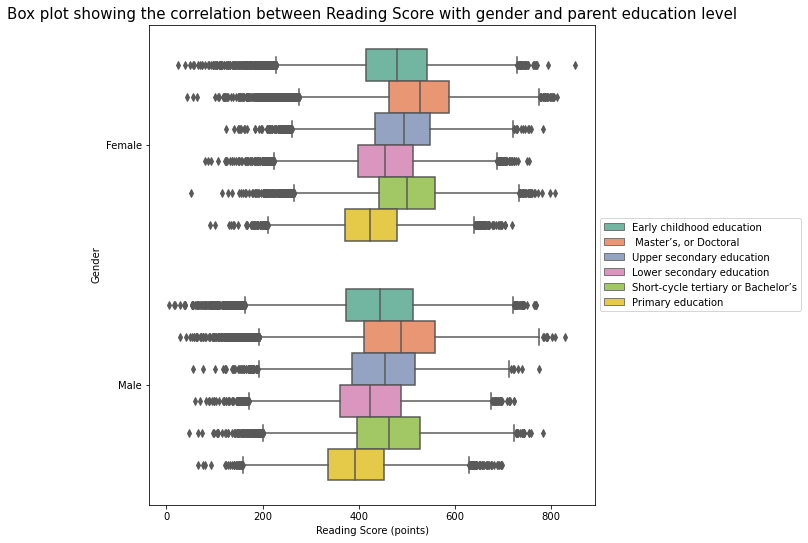

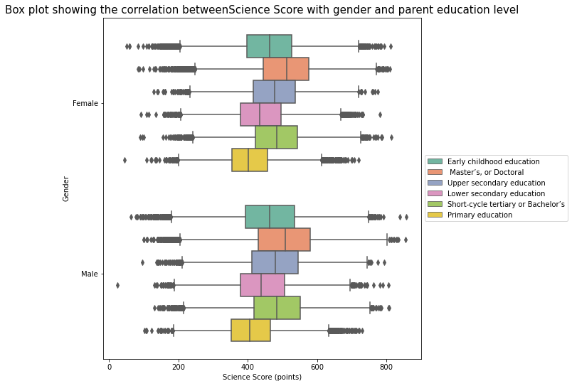